# WQD7002 Project

### A4 Software Diversity

#### Association of Software Diversity and Mobile Learning Readiness Factors

Based on Analysis of Variance:

- Significant contributors are F1 (Possibilities), F2 (Benefits), and F3 (Preferences) with p<0.0005
- The least contributor is F4 (External Influences)

```r
mod.a4 <- lm(`A4 Software Diversity` ~ `F1 Possibilities`+`F2 Benefits`+`F3 Preferences`+`F4 External Influences`, data=data2)
anova(mod.a4)
```

```
## Analysis of Variance Table
##
## Response: A4 Software Diversity
##                           Df  Sum Sq Mean Sq  F value Pr(>F)
## `F1 Possibilities`         1 0.65032 0.65032 1412.441 <2e-16 ***
## `F2 Benefits`              1 0.25516 0.25516  554.182 <2e-16 ***
## `F3 Preferences`           1 1.05754 1.05754 2296.881 <2e-16 ***
## `F4 External Influences`   1 0.00115 0.00115    2.496 0.1161
## Residuals                163 0.07505 0.00046
## ---
## Signif. codes:  0 '***' 0.001 '**' 0.01 '*' 0.05 '.' 0.1 ' ' 1
```

Based on regression analysis:

- The most significant contributor is F3 (Preferences) with p<2e-16
- The least contributor is F2 (Benefits) with p=0.76874

```r
summary(mod.a4)
```

```
##
## Call:
## lm(formula = `A4 Software Diversity` ~ `F1 Possibilities` + `F2 Benefits` +
##     `F3 Preferences` + `F4 External Influences`, data = data2)
##
## Residuals:
##       Min        1Q    Median        3Q       Max
## -0.034806 -0.007163 -0.001099  0.001698  0.098776
##
## Coefficients:
##                           Estimate Std. Error t value Pr(>|t|)
## (Intercept)              -0.114036   0.018661  -6.111 7.05e-09 ***
## `F1 Possibilities`        0.055495   0.018035   3.077  0.00245 **
## `F2 Benefits`            -0.008645   0.029353  -0.295  0.76874
## `F3 Preferences`          1.086123   0.022665  47.921  < 2e-16 ***
## `F4 External Influences` -0.017839   0.011292  -1.580  0.11608
## ---
## Signif. codes:  0 '***' 0.001 '**' 0.01 '*' 0.05 '.' 0.1 ' ' 1
##
## Residual standard error: 0.02146 on 163 degrees of freedom
## Multiple R-squared:  0.9632, Adjusted R-squared:  0.9623
## F-statistic:  1066 on 4 and 163 DF,  p-value: < 2.2e-16
```

```r
confint(mod.a4)
```

```
##                                2.5 %       97.5 %
## (Intercept)              -0.15088489 -0.077186218
## `F1 Possibilities`        0.01988281  0.091107679
## `F2 Benefits`            -0.06660666  0.049316556
## `F3 Preferences`          1.04136903  1.130877392
## `F4 External Influences` -0.04013611  0.004457507
```

```r
a4.ubeta <- c(summary(mod.a4)$coefficients["(Intercept)","Estimate"],summary(mod.a4)$coefficients["`F1 Possibilities`","Estimate"],summary(mod.a4)$coefficients["`F2 Benefits`","Estimate"],summary(mod.a4)$coefficients["`F3 Preferences`","Estimate"],summary(mod.a4)$coefficients["`F4 External Influences`","Estimate"])
a4.se <- c(summary(mod.a4)$coefficients["(Intercept)","Std. Error"],summary(mod.a4)$coefficients["`F1 Possibilities`","Std. Error"],summary(mod.a4)$coefficients["`F2 Benefits`","Std. Error"],summary(mod.a4)$coefficients["`F3 Preferences`","Std. Error"],summary(mod.a4)$coefficients["`F4 External Influences`","Std. Error"])
a4.tvalue <- c(summary(mod.a4)$coefficients["(Intercept)","t value"],summary(mod.a4)$coefficients["`F1 Possibilities`","t value"],summary(mod.a4)$coefficients["`F2 Benefits`","t value"],summary(mod.a4)$coefficients["`F3 Preferences`","t value"],summary(mod.a4)$coefficients["`F4 External Influences`","t value"])
a4.sig <- c(summary(mod.a4)$coefficients["(Intercept)","Pr(>|t|)"],summary(mod.a4)$coefficients["`F1 Possibilities`","Pr(>|t|)"],summary(mod.a4)$coefficients["`F2 Benefits`","Pr(>|t|)"],summary(mod.a4)$coefficients["`F3 Preferences`","Pr(>|t|)"],summary(mod.a4)$coefficients["`F4 External Influences`","Pr(>|t|)"])

a4.sbeta <- c('NA',summary(mod.a4)$coefficients["`F1 Possibilities`","Estimate"]*(sd(data2$`F1 Possibilities`)/sd(data2$`A4 Software Diversity`)),summary(mod.a4)$coefficients["`F2 Benefits`","Estimate"]*(sd(data2$`F2 Benefits`)/sd(data2$`A4 Software Diversity`)),summary(mod.a4)$coefficients["`F3 Preferences`","Estimate"]*(sd(data2$`F3 Preferences`)/sd(data2$`A4 Software Diversity`)),summary(mod.a4)$coefficients["`F4 External Influences`","Estimate"]/(sd(data2$`F4 External Influences`)/sd(data2$`A4 Software Diversity`)))

a4.table <- data.frame(a4.ubeta,a4.se,a4.sbeta,a4.tvalue,a4.sig)
colnames(a4.table) <- c('B','Std. Error','Beta','t','Sig.')
rownames(a4.table) <- c('(Constant)','F1 (Possibilities)','F2 (Benefits)','F3 (Preferences','F4 (External Influences)')

a4.table
```

```
##                                     B Std. Error                 Beta
## (Constant)               -0.114035554 0.01866144                   NA
## F1 (Possibilities)        0.055495246 0.01803504   0.0720621815960641
## F2 (Benefits)            -0.008645051 0.02935323 -0.00725605053229455
## F3 (Preferences           1.086123209 0.02266465    0.955762982516142
## F4 (External Influences) -0.017839303 0.01129167  -0.0110715186541423
##                                   t         Sig.
## (Constant)               -6.1107590 7.049049e-09
## F1 (Possibilities)        3.0770792 2.452677e-03
## F2 (Benefits)            -0.2945179 7.687369e-01
## F3 (Preferences          47.9214559 5.618851e-98
## F4 (External Influences) -1.5798640 1.160766e-01
```

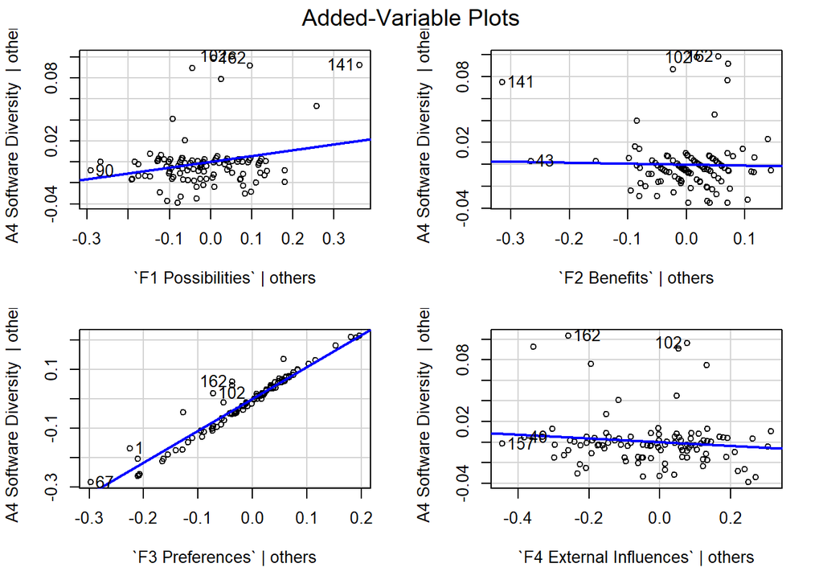

```r
avPlots(mod.a4)
```

Based on Pearson Product Moment Correlations:

- Software Diversity correlates the highest with F3 (Preferences) = 0.98 (p<0.001), followed by F2 (Benefits) = 0.65 (p<0.001)
- Software Diversity correlates the lowest with F4 (External Influences) = 0.33 (p<0.001)

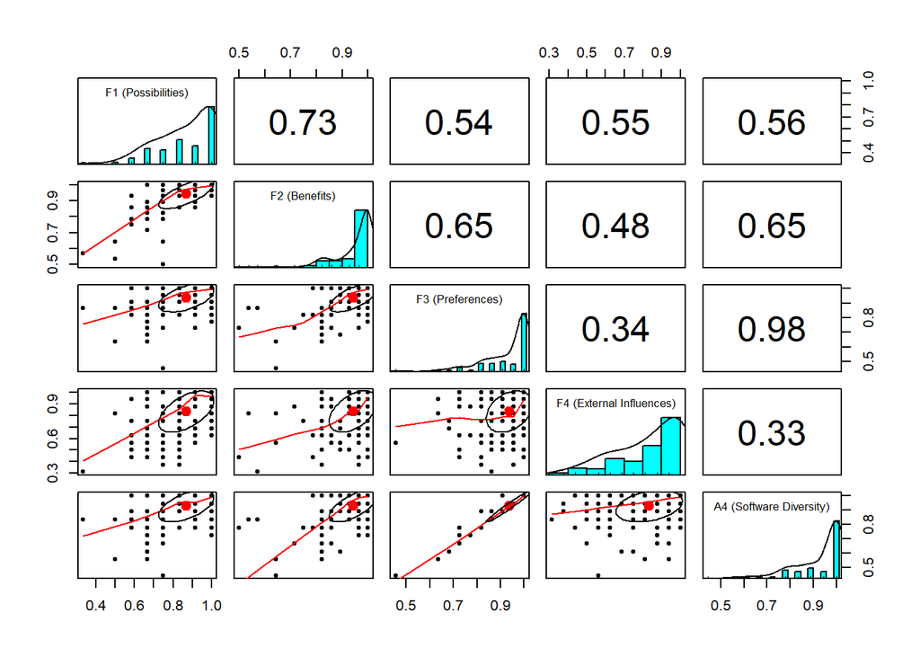

```r
data.a4 <- as.data.frame(rowMeans(factors2.f1))
names(data.a4)[1] <- "f1"
data.a4$f2 <- rowMeans(factors2.f2)
data.a4$f3 <- rowMeans(factors2.f3)
data.a4$f4 <- rowMeans(factors2.f4)
data.a4$a4 <- rowMeans(aspects.a4)

colnames(data.a4) <- c('F1 (Possibilities)','F2 (Benefits)','F3 (Preferences)','F4 (External Influences)','A4 (Software Diversity)')

pairs.panels(data.a4)
```

```r
cor(data.a4,method=c("pearson"))
```

```
##                          F1 (Possibilities) F2 (Benefits) F3 (Preferences)
## F1 (Possibilities)                1.0000000     0.7261724        0.5376028
## F2 (Benefits)                     0.7261724     1.0000000        0.6507084
## F3 (Preferences)                  0.5376028     0.6507084        1.0000000
## F4 (External Influences)          0.5529806     0.4772659        0.3373391
## A4 (Software Diversity)           0.5647190     0.6532779        0.9800857
##                          F4 (External Influences) A4 (Software Diversity)
## F1 (Possibilities)                      0.5529806               0.5647190
## F2 (Benefits)                           0.4772659               0.6532779
## F3 (Preferences)                        0.3373391               0.9800857
## F4 (External Influences)                1.0000000               0.3300581
## A4 (Software Diversity)                 0.3300581               1.0000000
```

```r
correlation::correlation(data.a4,include_factors = TRUE, method = "pearson")
```

```
## # Correlation Matrix (pearson-method)
##
## Parameter1               |               Parameter2 |    r |       95% CI | t(166) |         p
## ----------------------------------------------------------------------------------------------
## F1 (Possibilities)       |            F2 (Benefits) | 0.73 | [0.65, 0.79] |  13.61 | < .001***
## F1 (Possibilities)       |         F3 (Preferences) | 0.54 | [0.42, 0.64] |   8.21 | < .001***
## F1 (Possibilities)       | F4 (External Influences) | 0.55 | [0.44, 0.65] |   8.55 | < .001***
## F1 (Possibilities)       |  A4 (Software Diversity) | 0.56 | [0.45, 0.66] |   8.82 | < .001***
## F2 (Benefits)            |         F3 (Preferences) | 0.65 | [0.55, 0.73] |  11.04 | < .001***
## F2 (Benefits)            | F4 (External Influences) | 0.48 | [0.35, 0.59] |   7.00 | < .001***
## F2 (Benefits)            |  A4 (Software Diversity) | 0.65 | [0.56, 0.73] |  11.12 | < .001***
## F3 (Preferences)         | F4 (External Influences) | 0.34 | [0.20, 0.46] |   4.62 | < .001***
## F3 (Preferences)         |  A4 (Software Diversity) | 0.98 | [0.97, 0.99] |  63.59 | < .001***
## F4 (External Influences) |  A4 (Software Diversity) | 0.33 | [0.19, 0.46] |   4.50 | < .001***
##
## p-value adjustment method: Holm (1979)
## Observations: 168
```